# Supplementary analysis: analysis with seven realistic maps

## 0. Setup

```r
code_path='F:/Google Drive/post-doc/vitural_histology_revisit/new_code' # path to the code
realRes_path=file.path(code_path, 'real_res_raw')
```

## 1. Load functions

```r
library(knitr)
library(kableExtra)
library(ggplot2)
library(grid)
library(gridExtra)
library(dplyr)
source(file.path(code_path,'analysis_functions.R'))
source(file.path(code_path,'data_functions.R'))
source(file.path(code_path,'cor_functions.R'))
source(file.path(code_path,'spatial_functions.R'))
```

## 2. Load data

```r
res.files=list(
  spin_brain='Res_SynGO_int_abagen_r04_real_brain_spin_brain_5000_sim7.csv',
  random_gene='Res_SynGO_int_abagen_r04_real_brain_random_gene_5000_sim7.csv'
)
res2read=lapply(res.files, function(x) list.files(realRes_path, pattern=x, recursive =T, full.names=T))

# read res.files
res.df.list=lapply(res2read, read.csv, stringsAsFactors = F)
nest_by='brain'
pvals.nested=lapply(res.df.list, get_pvals_nested, nest_by=nest_by, heat_plot=F)
```

## 3. Results of competetive null models

### Figure S4. Results of transcriptional associations with realistic brain maps identified using competitive null models. The brain maps include effect sizes of case-control comparisons in attention deficit hyperactivity disorder (ADHD), autism spectrum disorder (ASD), bipolar disorder (BD), major depressive Disorder (MDD), obsessive-compulsive disorder (OCD), schizophrenia (SZC) and the first principal component (PC1) derived from the cortical thickness of 24,750 adult participants. Yellow squares indicate the significant associations that were determined using one of the following test statistics: Mean, Meanabs, Meansqr, Maxmean, Median, Sig Number, KS, Weighted KS, and compared against that from the competitive null models.

```r
brainLabel=c('ADHD','ASD','BD','MDD','OCD','SCZ','PC1')
pheat.list=lapply(pvals.nested, function(x){x %>% ungroup() %>%
                                          mutate(brainLabel=brainLabel,
                                            pheat=map2(pvals,brainLabel,heat_plot2_pvals_df),
                                            pheat_grob=map(pheat,as.grob))})
grid.arrange(grobs=pheat.list$random_gene$pheat_grob, ncol=7)
```

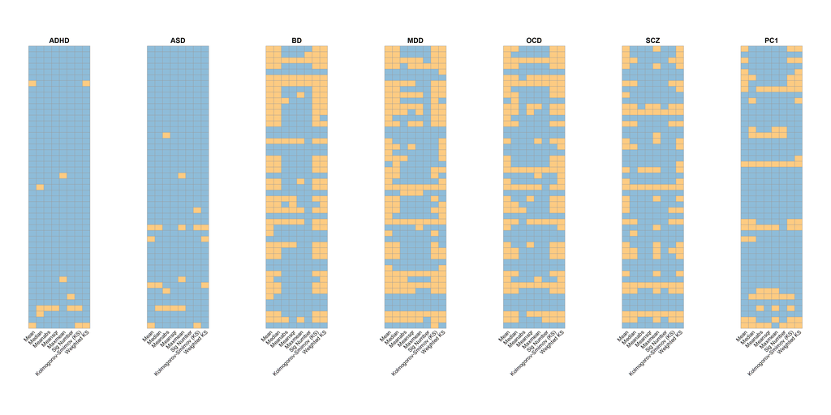

```r
grid.arrange(grobs=pheat.list$random_gene$pheat_grob, ncol=7)
```

## 4. Results of self-contained null models

### Figure S5. Results of transcriptional associations with realistic brain maps identified using self-contained models. The brain maps include effect sizes of case-control comparisons in attention deficit hyperactivity disorder (ADHD), autism spectrum disorder (ASD), bipolar disorder (BD), major depressive Disorder (MDD), obsessive-compulsive disorder (OCD), schizophrenia (SZC) and the first principal component (PC1) derived from the cortical thickness of 24,750 adult participants. Yellow squares indicate the significant associations that were determined using one of the following test statistics: Mean, Meanabs, Meansqr, Maxmean, Median, Sig Number, KS, Weighted KS and compared against that from the self-contained null models.

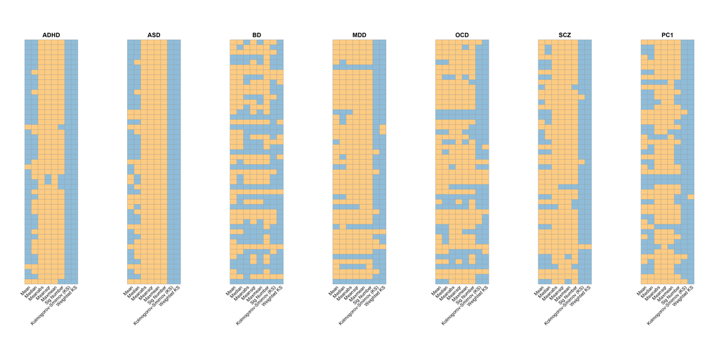

```r
grid.arrange(grobs=pheat.list$spin_brain$pheat_grob,
                   ncol=7)
```

## 5. Distribution of background correlation and measures of bimodality

### Figure S6. Distributions of background correlations for realistic brain maps. Each panel displays a histogram of correlations between a particular brain map with the transcriptional profiles of background genes, with the dip test statistic and the distance between the positive and negative modes shown as in texts. The x-axis of each histogram represents the correlation coefficient, and the y-axis represents the count of correlations falling within each bin. The ADHD, ASD, SCZ and PC1 show the clear separation between positive and negative correlations.

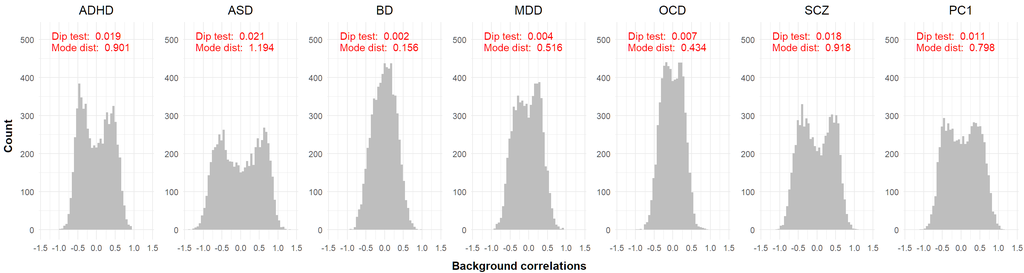

```r
# show bg correlat
brain_info=get_brain_info(data_path=file.path(code_path,'data'),
                          brainData_type = 'real_brain',
                          geneData_type = 'abagen_r04')

# to make density plot
gene_data=load_dk_gene_data(data_path=file.path(code_path,'data'),
                            type='abagen_r04',
                            hem='L')
brain_data=get_brain_data(data_path=file.path(code_path,'data'),
                          type='real_brain',
                          col_idx = NA) #NA means all cols
geneList=corr_brain_gene(gene_data=gene_data, brain_data=brain_data)

brain_maps = c("ADHD", "ASD", "BD", "MDD", "OCD", "SCZ", "PC1")
plist=list()
for (i in 1:7) {
  df2plot=data.frame(cor2plot=geneList[, i])
  # Create histogram plot
  p=ggplot(data = df2plot, aes(x = cor2plot)) +
    geom_histogram(bins = 50, fill = "grey") +
    xlim(c(-1.4,1.4))+
    ylim(c(0,520))+
    annotate("text", x = -1.2, y = 510,
             label = paste("Dip test: ", round(brain_info[i, "modetest_stat"], 3)),
             color = "red", hjust = 0) +
    annotate("text", x = -1.2, y = 480,
             label = paste("Mode dist: ", round(brain_info[i, "pos_neg_dist"], 3)),
             color = "red", hjust = 0)+
    ggtitle(brain_maps[i]) +
    xlab("Background correlations") +
    ylab("Count") +
    theme_minimal()+
    theme(axis.title.x = element_blank(),
          axis.title.y = element_blank(),
          plot.title = element_text(hjust = 0.5))

  # Add plot to list
  plist[[i]]=p
}
grid.arrange(grobs = plist, ncol = 7,
             left =textGrob("Count",gp=gpar(fontsize=12,font=2),rot=90),
             bottom=textGrob("Background correlations",gp=gpar(fontsize=12,font=2)))
```

## 6. Psig-B results

### Figure S7. Mean value and standard error (i.e., standard deviation/√7) of Psig-B across all realistic brain maps.

```r
psig.list=lapply(pvals.nested, get_psig, if_fdr=F)
```

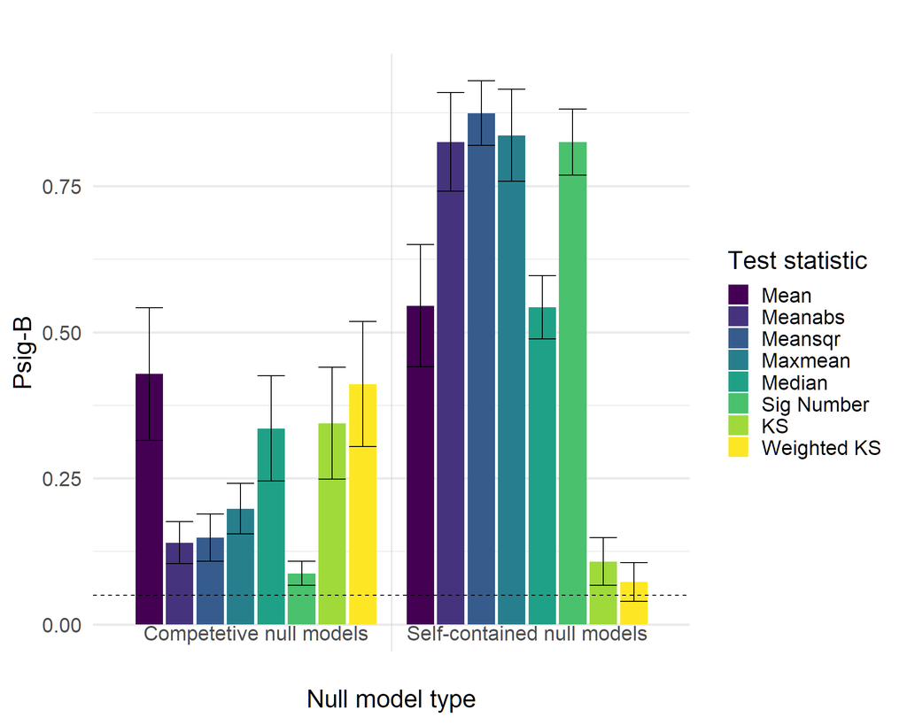

```r
#p1=plot_raw_psig_list(psig.list,show_shuffle = F, ylab2show = 'Psig-B', title2show = 'A.',title_adj = -0.086)
plot_summary_psig_list(psig.list,show_shuffle = F, ylab2show='Psig-B',title2show = '',title_adj = -0.10)
```